# gtrendsR_exemplo

O que quer dizer que a Google Trends Query de nenhuma forma pode ser considerada como uma resposta final, determinante ou condicionante que qualquer análise que se possa fazer, mas sim pode ser um ótimo primeiro passo para o início de uma investigação, pode ser um direcionador para entendermos o comportamento de mercado ou de opiniões em certo período do tempo, ou um simples aliado à outras técnicas que se desenvolve.

Brincando com esta ideia, vamos ver o que acontece quando olhamos para a mesma pequisa, trocando a localização para USA, ao invés do Brasil.

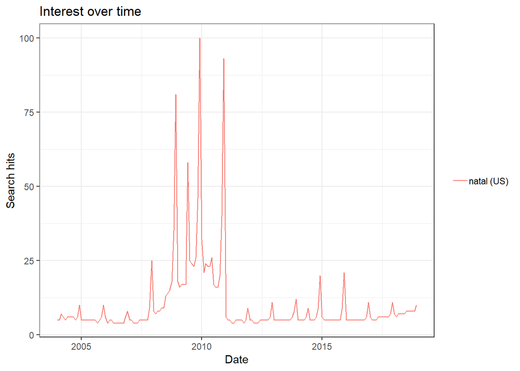

```r
List_natal_tudo_US <- gtrends(keyword="natal",geo=c("US"),time="all")
plot(List_natal_tudo_US)
```

Ops, acho que não era a palavra correta. Este aumento em 2009 e 2010 deve ser uma época em que havia muitos brasileiros nos Estados Unidos, ou muitos estadunidenses procurando férias nas praias de Natal. [joke]

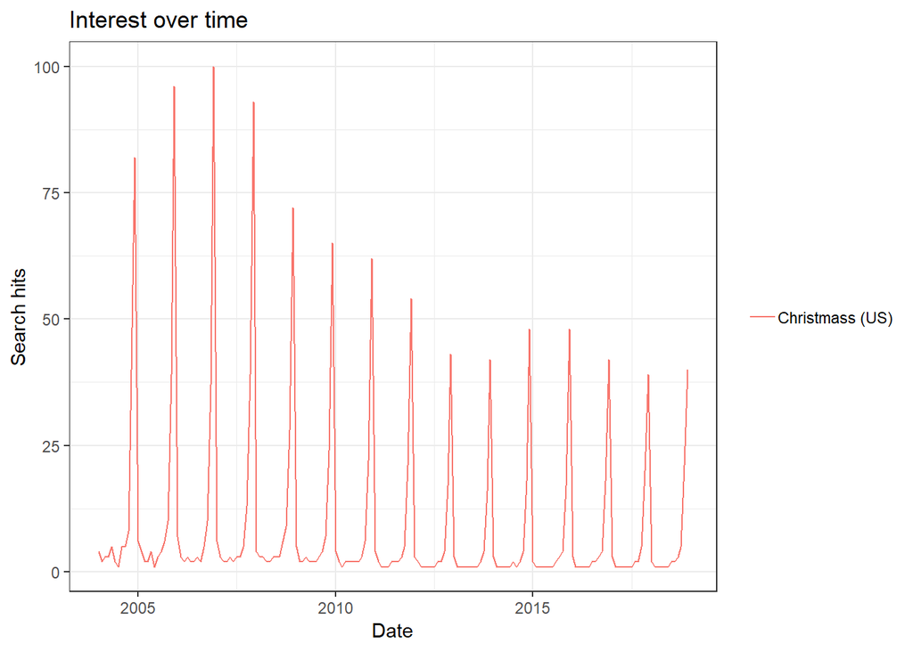

```r
List_christmass_tudo_US <- gtrends(keyword="Christmass",geo=c("US"),time="all")
plot(List_christmass_tudo_US)
```

Vemos um padrão de comportamento nos gráficos da popularidade parecido entre os dois países, no que se refere à frequencia anual, porém com uma dinâmica diferente, pois enquanto no Brasil vem decrescendo, tendo seu pico no início do período, nos Estados Unidos houve uma oscilação diferente.

Para terminar, vamos comparar palavras diferentes, relativos a datas específicas do ano.

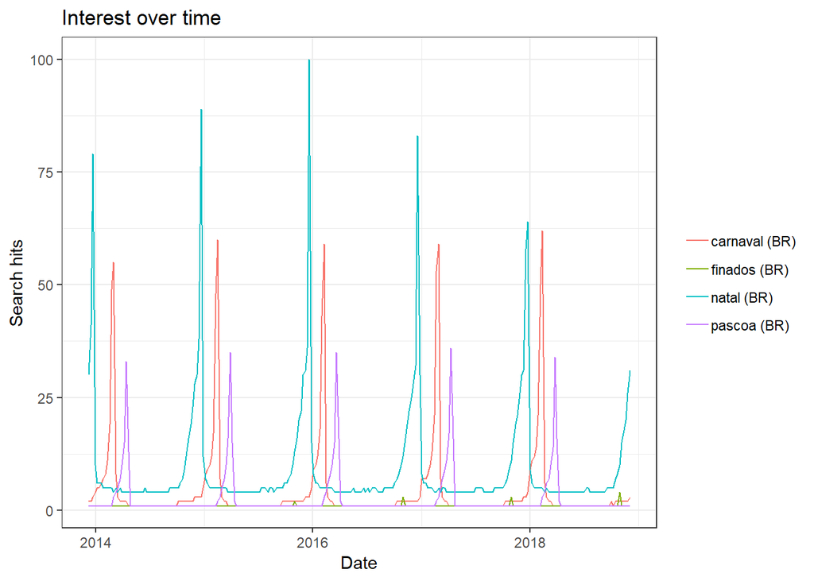

```r
List_comemorativas <- gtrends(keyword=c("carnaval","pascoa","finados","natal"),geo=c("BR"),time="today+5-y")
plot(List_comemorativas)
```